# Project 1

Sophia Telles & Samantha Driscoll

October 20, 2017

```r
load(file="providerspokane.rda")
```

```r
library(ggplot2)
library(dplyr)
library(tidyr)
library(RColorBrewer)
```

# Spokane Providers

## Intro

Medical providers in the Spokane area can be analyzed as a function of Gender of the provider, type of service provided, and place of service. These factors, when analyzed as functions of variables such as Medicare coverage, tell us a lot about what services in the medical field are used the most frequently, cost the most money, and have the most Medicare coverage.

## Question 1

Are there differences in the number of services, distinct beneficiary per day services, average medicare allowed, charged, and paid amount, and medicare standardized amount differ as a function of Gender, the Provider Type, and Place of Service?

# Gender

## Number of Services and Gender

```r
ServicesG=providerspokane%>%group_by(Gender=Gender.of.the.Provider)%>%summarize(NumberofServices =sum(Number.of.Services))
ServicesG[ServicesG==""] <-NA
ServicesG = ServicesG[complete.cases(ServicesG),]
```

We have some service providers that did not specify Gender, so we discovered a way to eliminate this variable of the data.

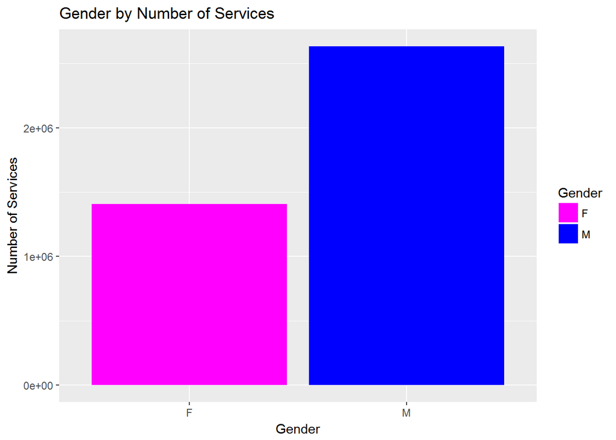

```r
ggplot(ServicesG,aes(Gender,NumberofServices,fill=Gender))+geom_bar(stat="identity")+scale_fill_manual(values=c("magenta","blue"))+ylab("Number of Services")+ggtitle("Gender by Number of Services")
```

## Number of Beneficiary per day Services and Gender

```r
BeneficiaryG=providerspokane%>%group_by(Gender = Gender.of.the.Provider)%>%summarize(NumberofBeneficiary=sum(Number.of.Distinct.Medicare.Beneficiary.Per.Day.Services))
BeneficiaryG[BeneficiaryG==""] <-NA
BeneficiaryG = BeneficiaryG[complete.cases(BeneficiaryG),]
```

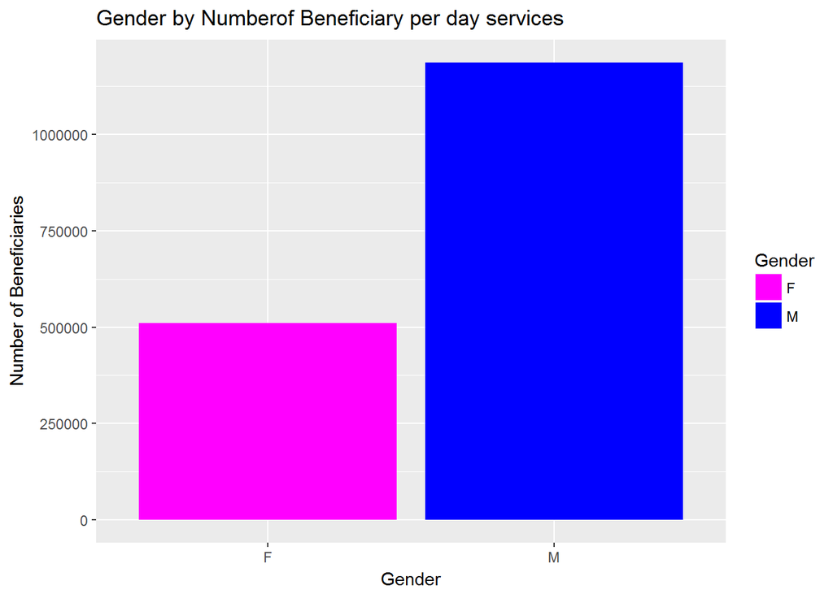

```r
ggplot(BeneficiaryG,aes(Gender,NumberofBeneficiary,fill=Gender))+geom_bar(stat="identity")+scale_fill_manual(values=c("magenta","blue"))+ylab("Number of Beneficiaries")+ggtitle("Gender by Numberof Beneficiary per day services")
```

## Average Medicare Allowed and Gender

```r
AllowedG=providerspokane%>%group_by(Gender=Gender.of.the.Provider)%>%summarize(AllowedAmmount=mean(Average.Medicare.Allowed.Amount))
AllowedG[AllowedG==""] <-NA
AllowedG = AllowedG[complete.cases(AllowedG),]
```

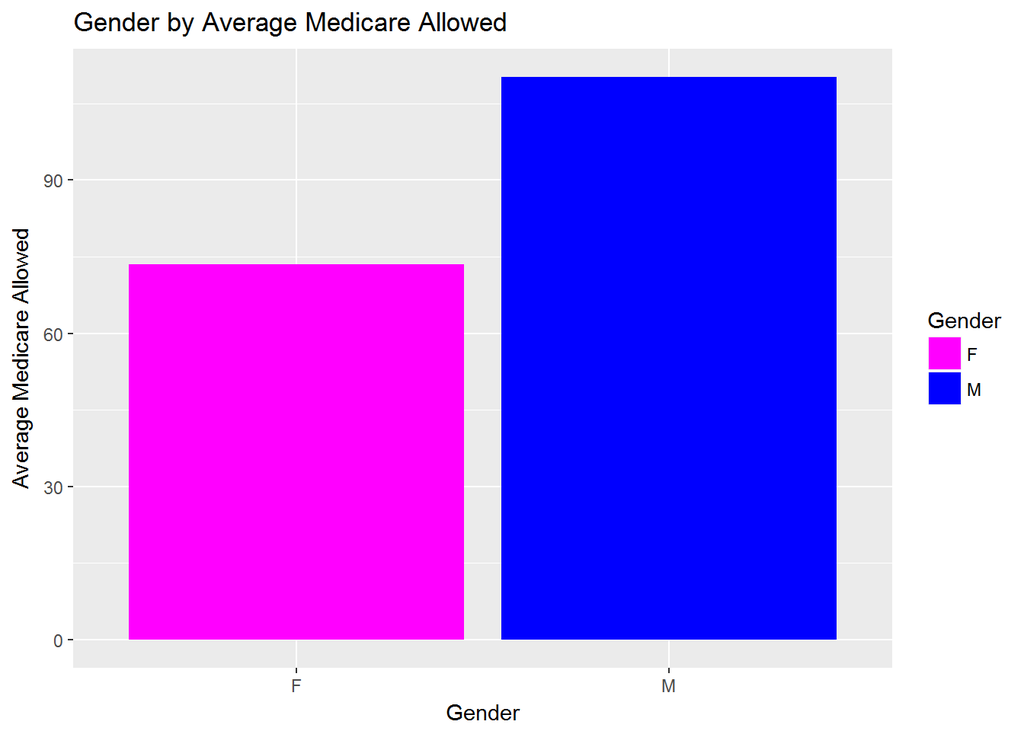

```r
ggplot(AllowedG,aes(Gender,AllowedAmmount,fill=Gender))+geom_bar(stat="identity")+scale_fill_manual(values=c("magenta","blue"))+ylab("Average Medicare Allowed")+ggtitle("Gender by Average Medicare Allowed")
```

## Average Submitted Charge Amount and Gender

```r
ChargedG=providerspokane%>%group_by(Gender=Gender.of.the.Provider)%>%summarize(ChargedAmmount=mean(Average.Submitted.Charge.Amount))
ChargedG[ChargedG==""] <-NA
ChargedG = ChargedG[complete.cases(ChargedG),]
```

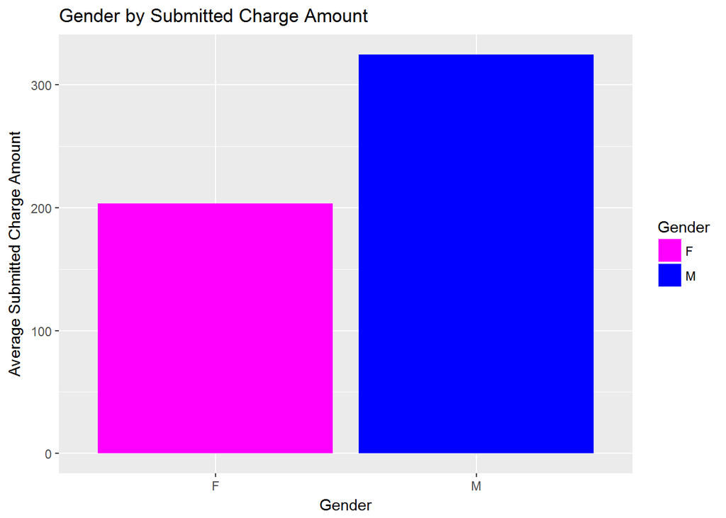

```r
ggplot(ChargedG,aes(Gender,ChargedAmmount,fill=Gender))+geom_bar(stat="identity")+scale_fill_manual(values=c("magenta","blue"))+ylab("Average Submitted Charge Amount")+ggtitle("Gender by Submitted Charge Amount")
```

## Average Medicare Payment Amount and Gender

```r
PaymentG=providerspokane%>%group_by(Gender=Gender.of.the.Provider)%>%summarize(PaymentAmmount=mean(Average.Medicare.Payment.Amount))
PaymentG[PaymentG==""] <-NA
PaymentG = PaymentG[complete.cases(PaymentG),]
```

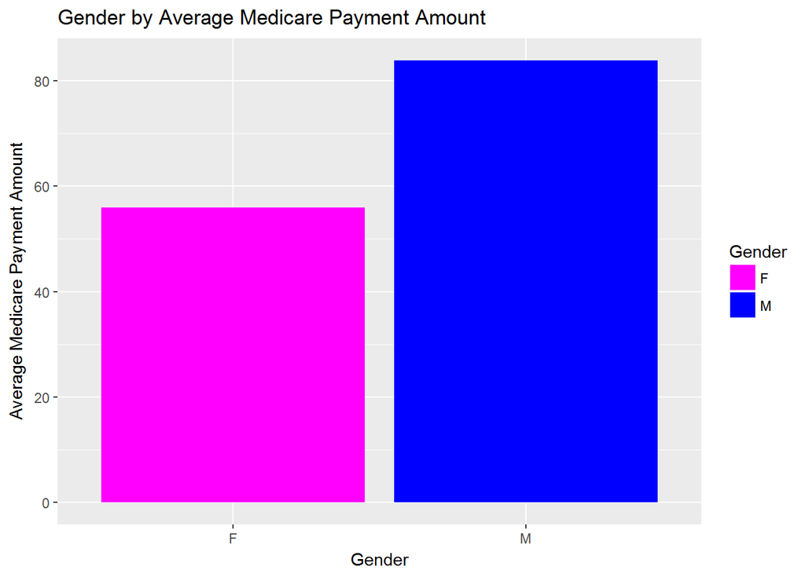

```r
ggplot(PaymentG,aes(Gender,PaymentAmmount,fill=Gender))+geom_bar(stat="identity")+scale_fill_manual(values=c("magenta","blue"))+ylab("Average Medicare Payment Amount")+ggtitle("Gender by Average Medicare Payment Amount")
```

## Average Medicare Standardized Amount and Gender

```r
StandardG=providerspokane%>%group_by(Gender=Gender.of.the.Provider)%>%summarize(StandardAmmount=mean(Average.Medicare.Standardized.Amount))
StandardG[StandardG==""] <-NA
StandardG = StandardG[complete.cases(StandardG),]
```

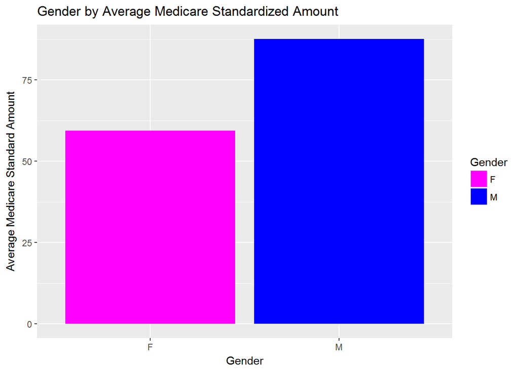

```r
ggplot(StandardG,aes(Gender,StandardAmmount,fill=Gender))+geom_bar(stat="identity")+scale_fill_manual(values=c("magenta","blue"))+ylab("Average Medicare Standard Amount")+ggtitle("Gender by Average Medicare Standardized Amount")
```

# Provider Type

## Number of Services and Provider Type

```r
ServicesP=providerspokane%>%group_by(Provider=Provider.Type)%>%summarize(NumberofServices =sum(Number.of.Services))
ServicesP <- ServicesP[order(-ServicesP$NumberofServices),]
ServicesP<-ServicesP[1:20,]
ServicesPs=providerspokane%>%group_by(Provider=Provider.Type)%>%summarize(NumberofServices =sum(Number.of.Services))
ServicesPs <- ServicesPs[order(-ServicesPs$NumberofServices),]
ServicesPs <-ServicesPs[21:45,]
ServicesPt=providerspokane%>%group_by(Provider=Provider.Type)%>%summarize(NumberofServices =sum(Number.of.Services))
ServicesPt <- ServicesPt[order(-ServicesPt$NumberofServices),]
ServicesPt <-ServicesPt[46:70,]
```

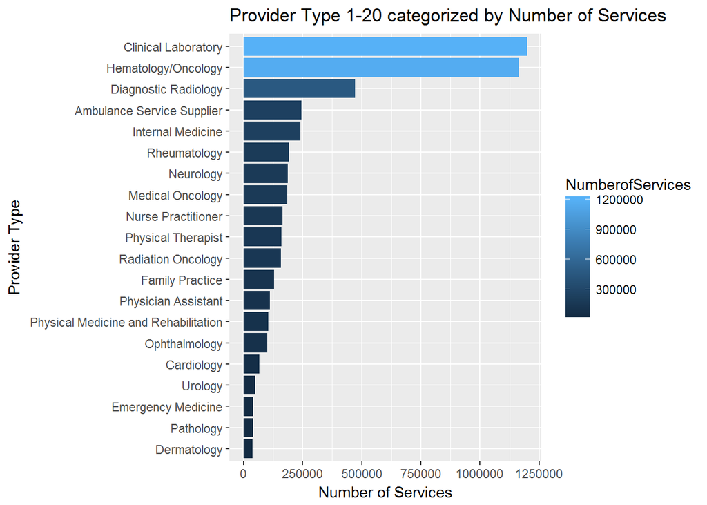

```r
ggplot(ServicesP,aes(reorder(Provider,NumberofServices),NumberofServices,fill=NumberofServices))+geom_bar(stat="identity")+coord_flip()+ylab("Number of Services")+xlab("Provider Type")+ggtitle("Provider Type 1-20 categorized by Number of Services")
```

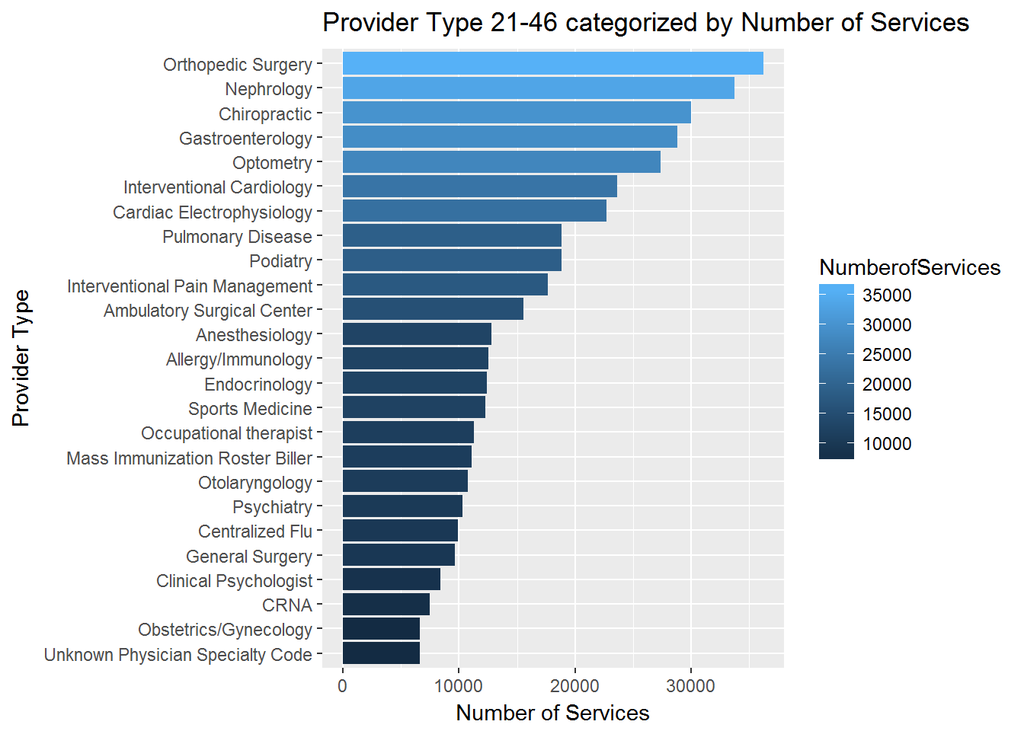

```r
ggplot(ServicesPs,aes(reorder(Provider,NumberofServices),NumberofServices,fill=NumberofServices))+geom_bar(stat="identity")+coord_flip()+ylab("Number of Services")+xlab("Provider Type")+ggtitle("Provider Type 21-46 categorized by Number of Services")
```

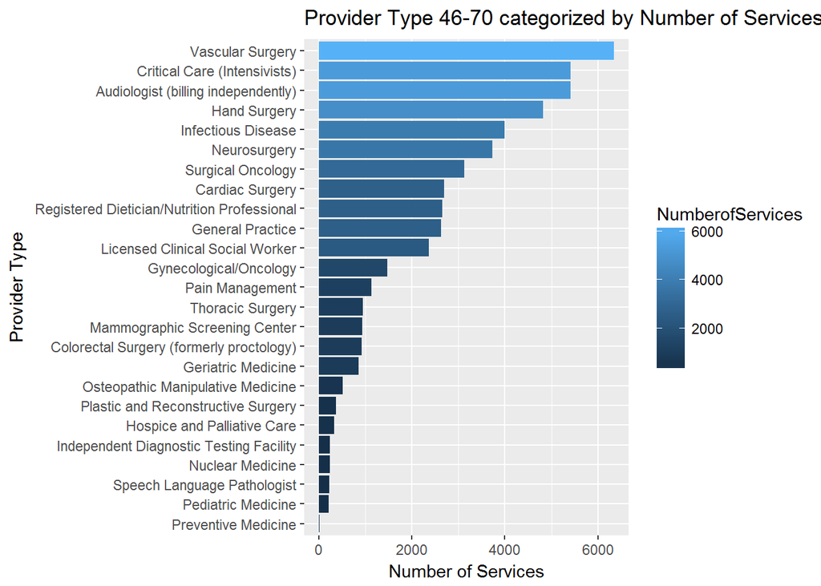

```r
ggplot(ServicesPt,aes(reorder(Provider,NumberofServices),NumberofServices,fill=NumberofServices))+geom_bar(stat="identity")+coord_flip()+ylab("Number of Services")+xlab("Provider Type")+ggtitle("Provider Type 46-70 categorized by Number of Services")
```

## Number of Beneficiary per day Services and Provider Type

```r
BeneficiaryP=providerspokane%>%group_by(Provider =Provider.Type)%>%summarize(NumberofBeneficiary=sum(Number.of.Distinct.Medicare.Beneficiary.Per.Day.Services))
BeneficiaryP <- BeneficiaryP[order(-BeneficiaryP$NumberofBeneficiary),]
BeneficiaryP <- BeneficiaryP[1:20,]
BeneficiaryPs=providerspokane%>%group_by(Provider =Provider.Type)%>%summarize(NumberofBeneficiary=sum(Number.of.Distinct.Medicare.Beneficiary.Per.Day.Services))
BeneficiaryPs <- BeneficiaryPs[order(-BeneficiaryPs$NumberofBeneficiary),]
BeneficiaryPs <- BeneficiaryPs[21:45,]
BeneficiaryPt=providerspokane%>%group_by(Provider =Provider.Type)%>%summarize(NumberofBeneficiary=sum(Number.of.Distinct.Medicare.Beneficiary.Per.Day.Services))
BeneficiaryPt <- BeneficiaryPt[order(-BeneficiaryPt$NumberofBeneficiary),]
BeneficiaryPt <- BeneficiaryPt[46:70,]
```

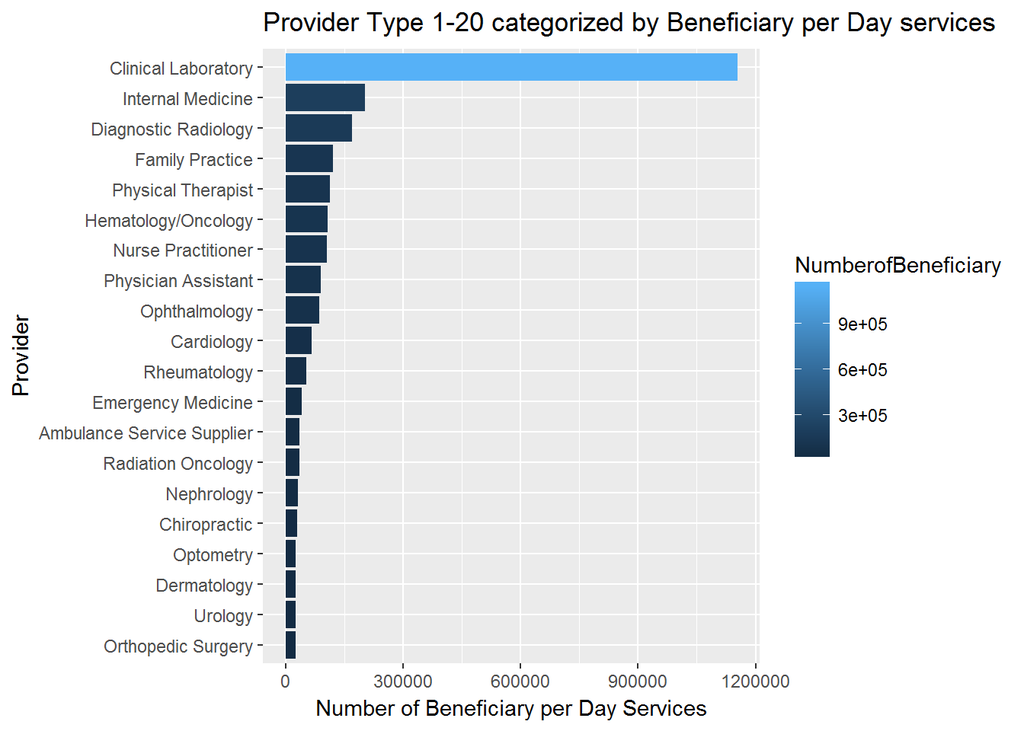

```r
ggplot(BeneficiaryP,aes(reorder(Provider,NumberofBeneficiary),NumberofBeneficiary, fill=NumberofBeneficiary))+geom_bar(stat="identity")+coord_flip()+ylab("Number of Beneficiary per Day Services")+xlab("Provider")+ggtitle("Provider Type 1-20 categorized by Beneficiary per Day services")
```

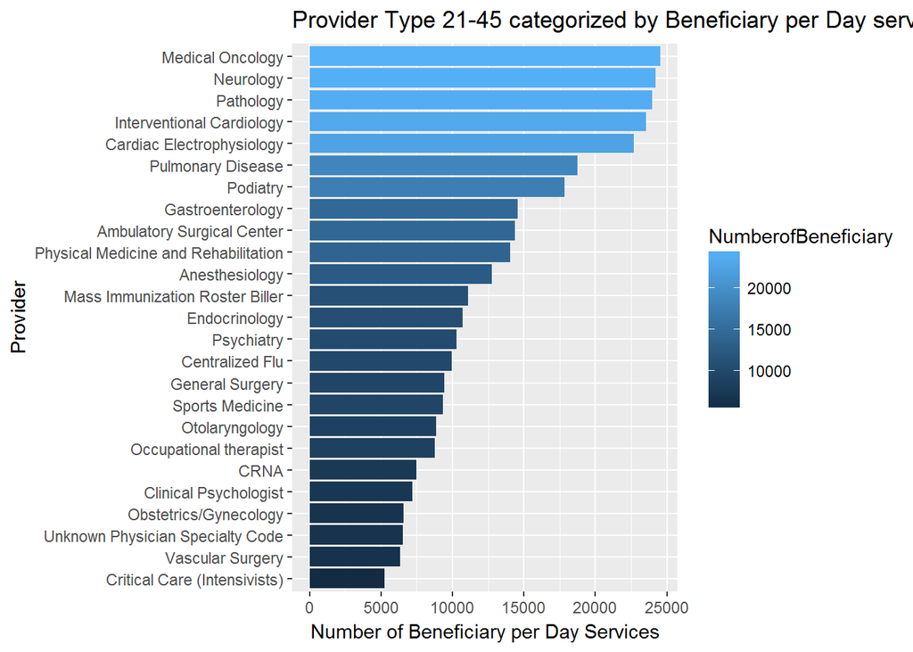

```r
ggplot(BeneficiaryPs,aes(reorder(Provider,NumberofBeneficiary),NumberofBeneficiary, fill=NumberofBeneficiary))+geom_bar(stat="identity")+coord_flip()+ylab("Number of Beneficiary per Day Services")+xlab("Provider")+ggtitle("Provider Type 21-45 categorized by Beneficiary per Day services")
```

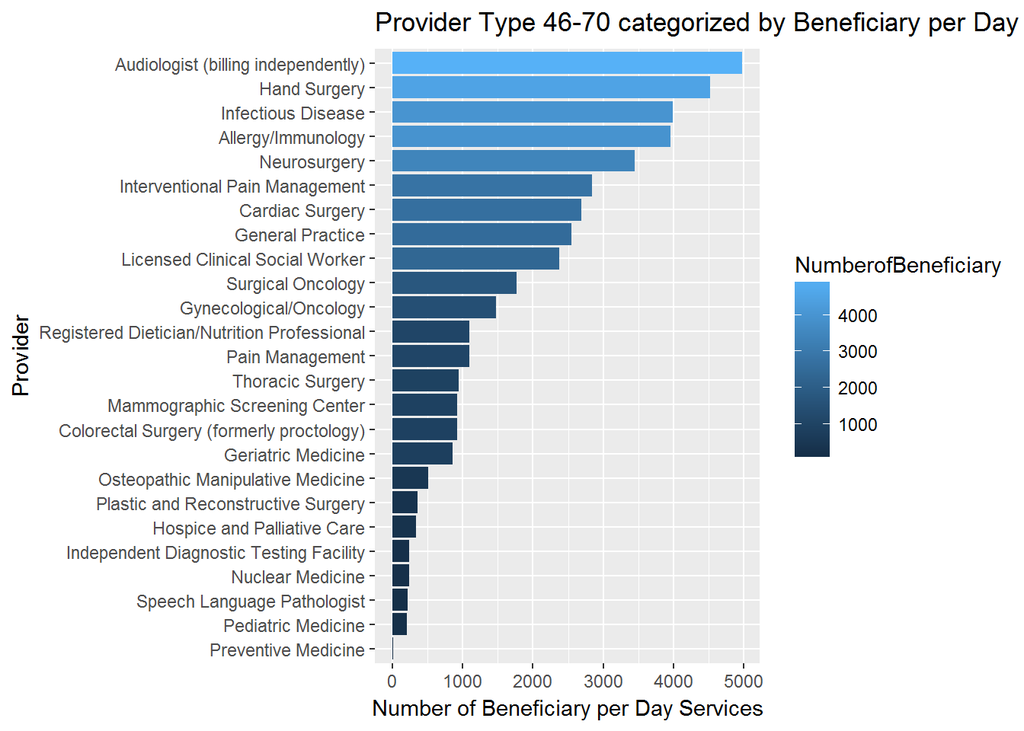

```r
ggplot(BeneficiaryPt,aes(reorder(Provider,NumberofBeneficiary),NumberofBeneficiary, fill=NumberofBeneficiary))+geom_bar(stat="identity")+coord_flip()+ylab("Number of Beneficiary per Day Services")+xlab("Provider")+ggtitle("Provider Type 46-70 categorized by Beneficiary per Day services")
```